# Step 1: Multi-exponential CW-OSL fitting at global average curve

Report of the Mittelstraß *et al.* (2019) Step 1 analysis of the data set **BT594** performed with the function `RLum.OSL_global_fitting()` from the **R** package `OSLdecomposition` 0.6.24 executed at 2020-06-30 12:45:51.

## Basics

We assume that all CW-OSL signal curves in this data set can be sufficently described by a sum of exponential decays with first order kinetics:

$$I(t) = \sum_{i=1}^K n_ie^{-\lambda_it}$$
Here, $I(t)$ is the CW-OSL signal, $K$ is the number of signal components. Each component is defined by its intensity $n$ and its decay rate $\lambda$.

To get component-seperated dose information, we divide the data analysis process into multiple steps:

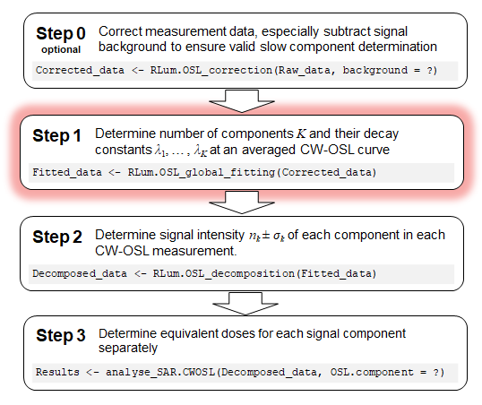

This report displays the results of Step 1, performed by `OSLdecomposition::RLum.OSL_global_fitting()`. The goal of Step 1 is to determine the number of components $K$ and their decay constants $\lambda_i$. We assume the decay constants are the same for all measurements in the data set and therefore global constants. Thus, we calculate one global average OSL curve and performed at it the multi-exponential fitting approach described by Bluszcz & Adamiec (2006).

## Results

### Best fitting

The global average curve of 336 OSL measurements was calculated and then fitted with multi-exponential decay models with an increasing number of components *K*. Then a statistical test compared the models and found the *K* = 3 model as sufficiently describing the global average curve (Table 1, Figure 1).

**Table 1:** Signal components of the K = 3 multi-exponential decay model chosen as best suiting fitting by an F-test. Each signal component is defined by its intensity $n$ and its decay contant $\lambda$, which can be converted in the photo-ionisation cross-section $\sigma$.  
First channel share: Average contribution to the signal at beginning of the measurement.  
Bleaching grade: Average approximated defect state depletion during the stimulation.

|  | $\lambda$ $(s^{-1})$ | $n$ (counts) | $\sigma$ (cm²) | first channel share | bleaching grade |
| --- | --- | --- | --- | --- | --- |
| Fast | 3.1659 | 1934 | 2.676e-17 | 78.9% | 100% |
| Medium | 0.7962 | 1143 | 6.73e-18 | 14.6% | 100% |
| Slow2 | 0.0164 | 22541 | 1.39e-19 | 6.4% | 28% |

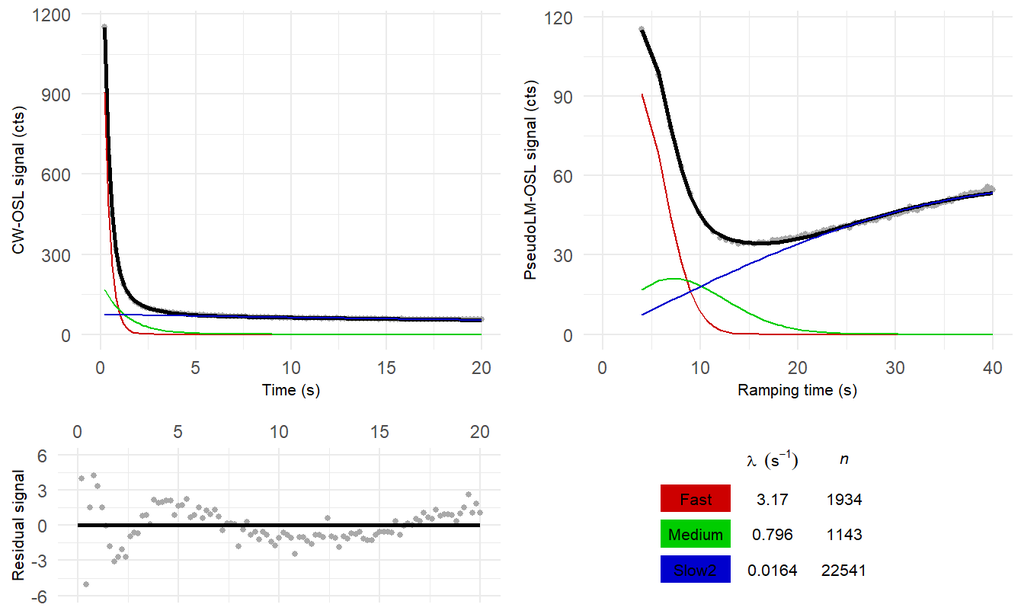

**Figure 1:** Fit model with K =3 (black), global average curve (grey) and signal components (colored)  
Upper left: Linear diagram. Upper right: pseudoLM-OSL diagram  
Lower left: Residual curve between fit and global average curve  
Lower right: Fitting result table with estimated type of component names

### Photo-ionisation cross-sections

The decay constant $\lambda_{k}$ of each component can be translated into the photo-ionisation cross-section $\sigma_{k}$ of the associated defect state:

$$\sigma_{k}=\lambda_{k} {hc \over I_{stim}\lambda_{stim}}$$
Here, $h$ is the [Planck constant](https://en.wikipedia.org/wiki/Planck_constant), $c$ is the [speed of light](https://en.wikipedia.org/wiki/Speed_of_light), $I_{stim}$ is the stimulation light intensity and $\lambda_{stim}$ is the stimulation light wavelength. If this wavelength is about ~ 470 nm and the measured sample material is quartz, then the resulting photo-ionisation cross-section can be compared with literature values, see figure 2.

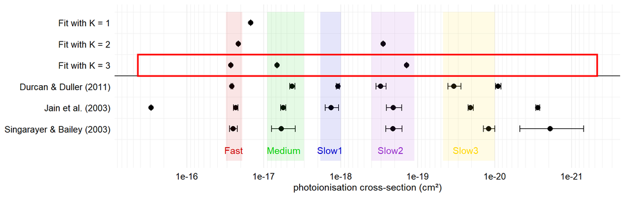

**Figure 2:** Comparison of the photo-ionisation cross-sections calculated from the signal component decay rates under the assumption of a stimulation light intensity of 50 mW/cm² and a stimulation light wavelength of 470 nm.  
Red rectangle: Fitting model choosen by the F-test.

Please be aware that the stimulation light intensity, displayed in the software of your OSL/TL reader, might differ from the actual stimulation light intensity. Degrading of the LEDs/lasers and the stimulation narrowing filters as well as a dirty chamber window glass can lead to significantly lower light intensities at the sample. In addition, the effective light intensity in the bulk material of the crystals depend on the reflectance and transmittance of the sample carrier, the fixation and the sample itself. Therefore, systematic shifts in the photo-ionisation cross-sections compared with literature values are likely. To manually correct for these shifts, apply the following rules when setting `RLum.OSL_global_fitting(stimulation_intensity = ?)`:

- **Increase** intensity value to shift the fitted cross-sections towards **right**
- **Decrease** intensity value to shift the fitted cross-sections towards **left**

## Methods

### Global average curve

For calculating the decay parameters, one representative OSL curve is needed. This is provided by combining all measurements to one global average curve. Each data point of this global curve represents the arithmetic mean of all data point values of the same channel in all OSL curves. This increases the signal-to-noise ratio by about one to two orders of magnitude, but still maintains the decay parameter information.

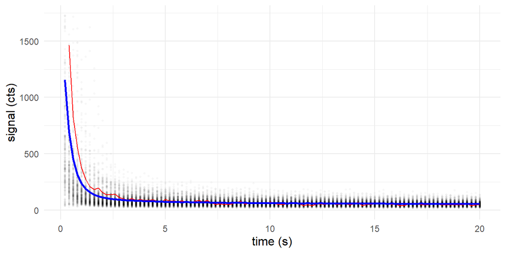

**Figure 3:** Blue line: Global average curve built from the arithmetic mean of all curves.  
Grey points: Data from all measurements. Red: First measurement of the data set.

### Multi-exponential fitting

We take the global mean curve and perform multiple cycles of multi-exponential nonlinear regression. In each cycle, the number of components *K* increases by one. With increasing number of components, decreases the residual curve between the fitted model curve and the measured data and the fit gets better.

The underlying algorithm was proposed and described by Bluszcz & Adamiec (2006) and realized in **R** by the function `numOSL::decomp()` by Peng *et al.* (2013). Their function is used in `fit_OSLcurve()`, which calculated the following series of fittings:

#### K = 1

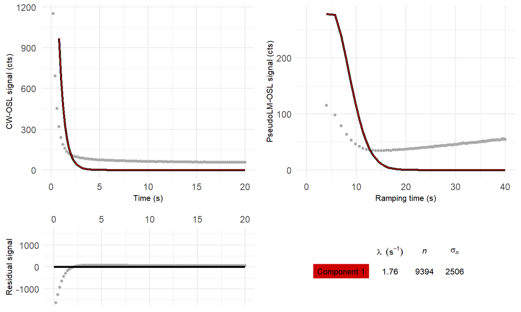

**Figure 4.1:** Fit model with K = 1 (black), global average curve (grey) and signal components (colored)  
Upper left: Linear diagram. Upper right: pseudoLM-OSL diagram  
Lower left: Residual curve between fit and global average curve  
Lower right: Fitting result table with estimated type of component names

#### K = 2

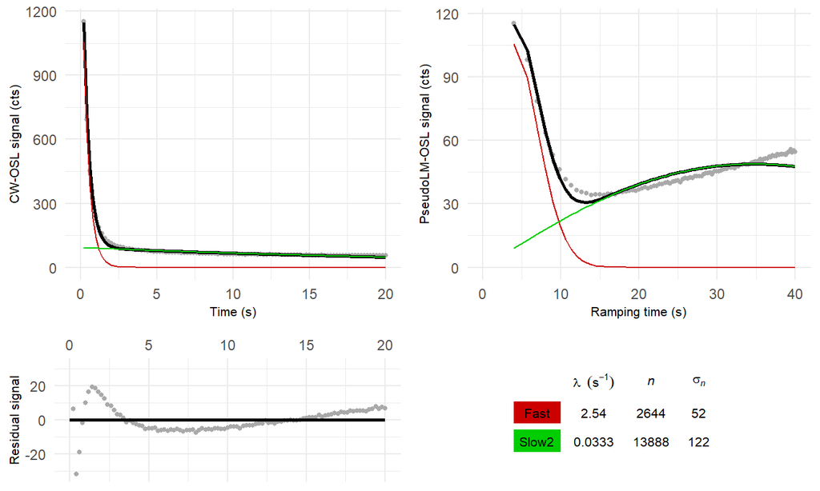

**Figure 4.2:** Fit model with K = 2 (black), global average curve (grey) and signal components (colored)  
Upper left: Linear diagram. Upper right: pseudoLM-OSL diagram  
Lower left: Residual curve between fit and global average curve  
Lower right: Fitting result table with estimated type of component names

#### K = 3

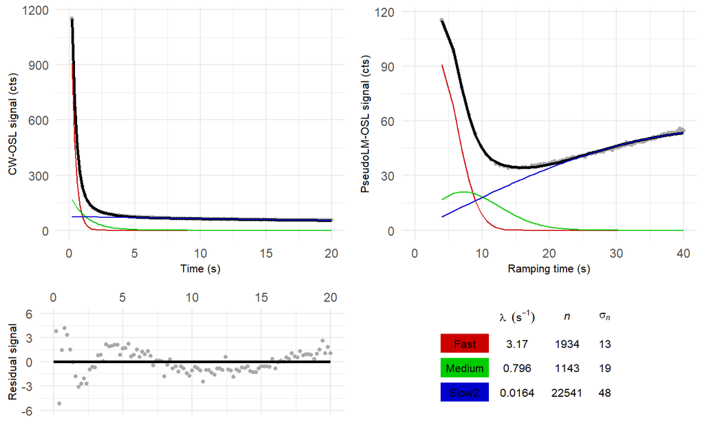

**Figure 4.3:** Fit model with K = 3 (black), global average curve (grey) and signal components (colored)  
Upper left: Linear diagram. Upper right: pseudoLM-OSL diagram  
Lower left: Residual curve between fit and global average curve  
Lower right: Fitting result table with estimated type of component names

### F-test

But which of these fittings gives back a sufficient model of the global mean curve, without over-fitting it? We solve this by comparing the residual square sum (*RSS*) of each fitting with the *RSS* value of the previous fitting. Bluszcz & Adamiec (2006) propose to use a *F*-test:

$$F_K = \frac{(RSS_{K-1} - RSS_K)/2}{RSS_K(N - 2K)}$$

Here, *N* is the number data points (channels) of the global average curve and *K* is the number of OSL components in the fitting model. If the *F*-value *F<sub>K</sub>* falls below the preset threshold value of *F<sub>threshold</sub>* = 150, the new fitting model with *K* components is apparently not significantly better than the *K* - 1 model and will be chosen as algorithm output.

**Table 2:** Decay constants and fitting quality parameters in dependence of component number $K$.  
RSS: Residual square sum. $F_K$: Measure of fitting improvement.

| $K$ | $\lambda_1$ $(s^{-1})$ | $\lambda_2$ $(s^{-1})$ | $\lambda_3$ $(s^{-1})$ | RSS | $F_K$ |
| --- | --- | --- | --- | --- | --- |
| 1 | 1.7575 |  |  | 3.989e+05 | Inf |
| 2 | 2.5446 | 0.0333 |  | 4843 | 3905 |
| 3 | 3.1659 | 0.7962 | 0.0164 | 215.9 | 1007 |

The fitting with *K* = 3 components is found to be the best suiting model to describe the given sample. Signal components with not-first-order kinetics, however, can lead to over-fitting. In case of more than 3 components, it is recommended to take the results of the *K* = 2 fitting model also into consideration.

## Acknowledgment

This report was automatically generated by functions of the **R** package `OSLdecomposition` written and maintained by Dirk Mittelstraß (dirk.mittelstrass@luminescence.de). The data analysis process deploys also functions and concepts of the **R** packages `numOSL` ([link](https://cran.r-project.org/package=numOSL)) introduced by Peng *et al.* (2013) and `Luminescence` ([link](https://cran.r-project.org/package=Luminescence)) introduced by Kreutzer *et al.* (2012). For the dynamic creation of this HTML report, the **R** packages `knitr` and `rmarkdown` are used, see Xie (2015) and Xie *et al.* (2018). All diagrams are drawn with `ggplot2` (Wickham 2016).

You can use, share and publish this report and the containing results at will, as long as you have the consent of the measurement data maintainer. If this report or its results are published, however, it is requested to refer to the main **R** package `OSLdecomposition` including its version number (0.6.24). It is also demanded to include the following reference into your publication:

**Mittelstraß D., Schmidt C., Beyer J., and Straessner A., 2019. Automated identification and separation of quartz CW-OSL signal components with R. talk presented at the Central European Conference on Luminescence and Trapped-Charge dating: DLED 2019, Bingen, Germany**  
http://luminescence.de/OSLdecomp_talk.pdf  
*(reference will be replaced as soon as peer-reviewed publication is accepted)*

There, you can find a full description of the method and the algorithms involved, as well as some simulation-based performance tests.

It is allowed and encouraged to add the HTML file of this report to the electronical supplement of your publication.

## References

Bluszcz, A., Adamiec, G., 2006. Application of differential evolution to fitting OSL decay curves. Radiation Measurements 41, 886–891.  
https://doi.org/10.1016/j.radmeas.2006.05.016

Durcan, J.A., Duller, G.A.T., 2011. The fast ratio: A rapid measure for testing the dominance of the fast component in the initial OSL signal from quartz. Radiation Measurements 46, 1065–1072.  
https://doi.org/10.1016/j.radmeas.2011.07.016

Jain, M., Murray, A.S., Bøtter-Jensen, L., 2003. Characterisation of blue-light stimulated luminescence components in different quartz samples: implications for dose measurement. Radiation Measurements 37, 441–449.  
https://doi.org/10.1016/S1350-4487(03)00052-0

Kreutzer, S., Schmidt, C., Fuchs, M.C., Dietze, M., Fuchs, M., 2012. Introducing an R package for luminescence dating analysis. Ancient TL 30.  
http://ancienttl.org/ATL_30-1_2012/ATL_30-1_Kreutzer_p1-8.pdf

Peng, J., Dong, Z., Han, F., Long, H., Liu, X., 2013. R package numOSL: numeric routines for optically stimulated luminescence dating. Ancient TL 31.  
http://ancienttl.org/ATL_31-2_2013/ATL_31-2_Peng_p41-48.pdf

Singarayer, J.S., Bailey, R.M., 2003. Further investigations of the quartz optically stimulated luminescence components using linear modulation. Radiation Measurements, Proceedings of the 10th international Conference on Luminescence and Electron-Spin Resonance Dating (LED 2002) 37, 451–458.  
https://doi.org/10.1016/S1350-4487(03)00062-3

Wickham, H., 2016. ggplot2: elegant graphics for data analysis, Second edition. ed, Use R! Springer, Cham.  
https://ggplot2.tidyverse.org/

Xie, Y., 2015. Dynamic documents with R and Knitr, Second edition. ed. CRC Press/Taylor & Francis, Boca Raton.  
https://yihui.org/knitr/

Xie, Y., Allaire, J.J., Grolemund, G., 2018. R Markdown: the definitive guide. Taylor & Francis, CRC Press, Boca Raton.  
https://bookdown.org/yihui/rmarkdown/

## Script parameters

| **Settings** |  |
| --- | --- |
| Analyzed data set | BT594 |
| Analyzed record type | OSL |
| Maximum allowed components | *K*<sub>max</sub> = 3 |
| Threshold *F*-value | *F*<sub>threshold</sub> = 150 |
| **Photo-ionisation cross-section parameter** |  |
| Stimulation wavelength | 470 nm |
| Stimulation intensity | 50 mW/cm² |
| **Global curve properties** |  |
| No. of input measurements | 336 |
| No. of input sequences | 24 |
| Channel time | $\delta$*t* = 0.2 s |
| Channels | *N* = 100 |
| Global curve length | *t* = *N*$\delta$*t* = 20 s |

Last major change in the script code: 2020-05-09 by D. Mittelstraß

**Session info:**

R version 3.6.3 (2020-02-29) Platform: i386-w64-mingw32/i386 (32-bit) Running under: Windows 10 x64 (build 18362)

Matrix products: default

attached base packages: [1] stats graphics grDevices utils datasets methods base

other attached packages: [1] scales_1.1.0 ggpubr_0.2.5 gridExtra_2.3 ggplot2_3.3.0  
[5] knitr_1.28 kableExtra_1.1.0 rmarkdown_2.1 numOSL_2.6  
[9] OSLdecomposition_0.6.24 Luminescence_0.9.7 magrittr_1.5